# MATH 3070 Lab Project 7

Kyle Kazemini

October 3, 2019

*Remember: I expect to see commentary either in the text, in the code with comments created using `#`, or (preferably) both! **Failing to do so may result in lost points!***

## Problem 1

*For the `batting` (**UsingR**) data set, make parallel boxplots of the batting average (`H/AB`) for each team. Which team had the greatest median average? (Use **lattice** functions for this problem.)*

```r
library(UsingR)
data("batting")
str(batting) #Displays structure
```

```
## 'data.frame':    438 obs. of  22 variables:
##  $ playerID: Factor w/ 1217 levels "abbotpa01","abernbr01",..: 1207 1125 1107 1086 996 928 679 648 648 630 ...
##  $ yearID  : num  2002 2002 2002 2002 2002 ...
##  $ stintID : num  1 1 1 1 1 1 1 2 1 2 ...
##  $ teamID  : Factor w/ 30 levels "ANA","ARI","ATL",..: 11 21 28 16 9 29 24 18 11 4 ...
##  $ lgID    : Factor w/ 2 levels "AL","NL": 1 1 1 2 1 1 2 2 1 1 ...
##  $ G       : num  54 56 44 62 65 69 76 90 33 52 ...
##  $ AB      : num  201 133 168 137 159 158 185 231 107 109 ...
##  $ R       : num  25 22 17 16 15 17 19 33 10 10 ...
##  $ H       : num  57 30 36 34 34 33 44 59 25 23 ...
##  $ DOUBLE  : num  14 8 2 9 7 4 3 17 4 6 ...
##  $ TRIPLE  : num  0 0 1 2 2 0 0 1 0 0 ...
##  $ HR      : num  7 2 0 8 6 4 2 7 0 2 ...
##  $ RBI     : num  27 8 9 24 21 14 19 33 6 9 ...
##  $ SB      : num  2 3 7 1 0 4 1 5 3 1 ...
##  $ CS      : num  0 0 1 0 1 2 1 6 2 0 ...
##  $ BB      : num  12 15 7 7 15 17 9 13 8 3 ...
##  $ SO      : num  39 32 19 38 27 45 33 44 13 20 ...
##  $ IBB     : num  5 1 0 0 2 0 0 0 0 0 ...
##  $ HBP     : num  2 5 1 2 0 5 2 1 1 0 ...
##  $ SH      : num  0 1 3 0 0 4 3 4 4 0 ...
##  $ SF      : num  1 1 1 0 2 2 1 3 1 0 ...
##  $ GIDP    : num  12 4 1 7 4 2 5 2 4 3 ...
```

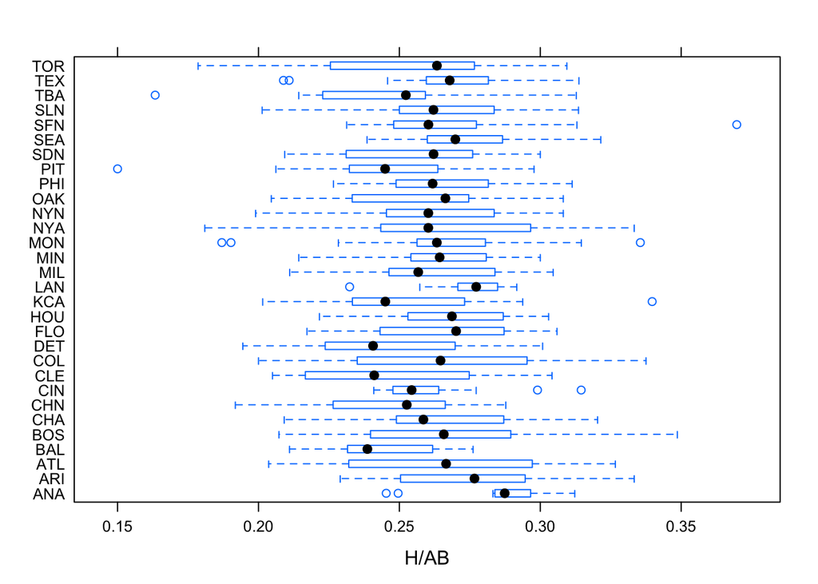

```r
library(lattice) #Loads library
bwplot(teamID ~ H/AB, data= batting) #creates lattice plot for each team
```

```r
#The team with the greatest median average is ANA
```

## Problem 2

*For the `mtcars` data set, produce graphics of the following using **ggplot2**:*

1. *Boxplots for miles per gallon (`mpg`) for groups defined by the number of gears (`gear`).*

```r
data("mtcars")
str(mtcars)
```

```
## 'data.frame':    32 obs. of  11 variables:
##  $ mpg : num  21 21 22.8 21.4 18.7 18.1 14.3 24.4 22.8 19.2 ...
##  $ cyl : num  6 6 4 6 8 6 8 4 4 6 ...
##  $ disp: num  160 160 108 258 360 ...
##  $ hp  : num  110 110 93 110 175 105 245 62 95 123 ...
##  $ drat: num  3.9 3.9 3.85 3.08 3.15 2.76 3.21 3.69 3.92 3.92 ...
##  $ wt  : num  2.62 2.88 2.32 3.21 3.44 ...
##  $ qsec: num  16.5 17 18.6 19.4 17 ...
##  $ vs  : num  0 0 1 1 0 1 0 1 1 1 ...
##  $ am  : num  1 1 1 0 0 0 0 0 0 0 ...
##  $ gear: num  4 4 4 3 3 3 3 4 4 4 ...
##  $ carb: num  4 4 1 1 2 1 4 2 2 4 ...
```

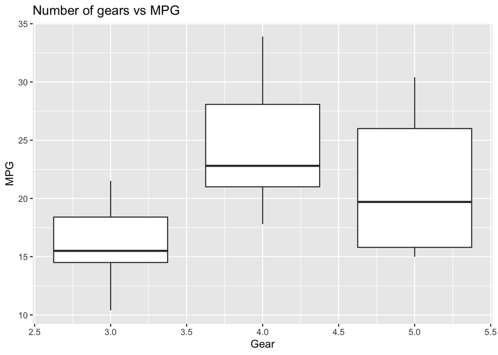

```r
library(ggplot2)
q <- ggplot(mtcars, aes(y= mpg, x= gear, group = gear)) + #Creates plots for each gear
  xlab("Gear") +
  ylab("MPG") + #Names
  ggtitle("Number of gears vs MPG")
q + geom_boxplot() #Creates boxplots
```

3. *A scatterplot of `mpg` modeled by horsepower (`hp`). Create facets by the number of cylinders (`cyl`) and `gear`.*

```r
str(mtcars) #Displays structure
```

```
## 'data.frame':    32 obs. of  11 variables:
##  $ mpg : num  21 21 22.8 21.4 18.7 18.1 14.3 24.4 22.8 19.2 ...
##  $ cyl : num  6 6 4 6 8 6 8 4 4 6 ...
##  $ disp: num  160 160 108 258 360 ...
##  $ hp  : num  110 110 93 110 175 105 245 62 95 123 ...
##  $ drat: num  3.9 3.9 3.85 3.08 3.15 2.76 3.21 3.69 3.92 3.92 ...
##  $ wt  : num  2.62 2.88 2.32 3.21 3.44 ...
##  $ qsec: num  16.5 17 18.6 19.4 17 ...
##  $ vs  : num  0 0 1 1 0 1 0 1 1 1 ...
##  $ am  : num  1 1 1 0 0 0 0 0 0 0 ...
##  $ gear: num  4 4 4 3 3 3 3 4 4 4 ...
##  $ carb: num  4 4 1 1 2 1 4 2 2 4 ...
```

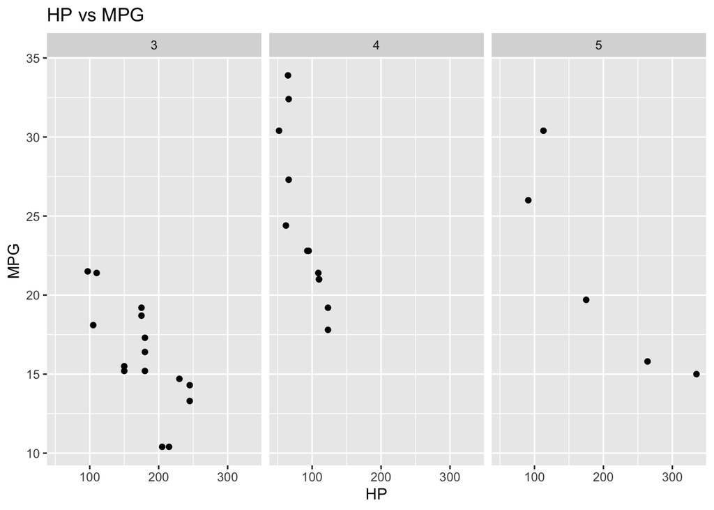

```r
q <- ggplot(mtcars, aes(y= mpg, x= hp)) + #Creates plot
  xlab("HP") +
  ylab("MPG") + #Names
  ggtitle("HP vs MPG") +
  facet_grid(.~ cyl) + #Facet for cylinders
  facet_grid(.~ gear) #Facet for gears
q + geom_point() #Creates scatterplot
```

## Problem 3

*Using the `batting` data set (UsingR), create a visualization that does the following:*

- *Plots the* rate *of intentional walks (that is, the number of intentional walks divided by the number of times a player was at bat; these are the `IBB` and `AB` variables in the data set, respectively) against the* rate *of home runs (the `HR` variable in the data set) as a scatterplot*
- *Draws a trend line for these variables*
- *Identifies the outlier in the data set in these variables (spotted once the scatter plot is drawn)*

```r
str(batting) #Displays structure
```

```
## 'data.frame':    438 obs. of  22 variables:
##  $ playerID: Factor w/ 1217 levels "abbotpa01","abernbr01",..: 1207 1125 1107 1086 996 928 679 648 648 630 ...
##  $ yearID  : num  2002 2002 2002 2002 2002 ...
##  $ stintID : num  1 1 1 1 1 1 1 2 1 2 ...
##  $ teamID  : Factor w/ 30 levels "ANA","ARI","ATL",..: 11 21 28 16 9 29 24 18 11 4 ...
##  $ lgID    : Factor w/ 2 levels "AL","NL": 1 1 1 2 1 1 2 2 1 1 ...
##  $ G       : num  54 56 44 62 65 69 76 90 33 52 ...
##  $ AB      : num  201 133 168 137 159 158 185 231 107 109 ...
##  $ R       : num  25 22 17 16 15 17 19 33 10 10 ...
##  $ H       : num  57 30 36 34 34 33 44 59 25 23 ...
##  $ DOUBLE  : num  14 8 2 9 7 4 3 17 4 6 ...
##  $ TRIPLE  : num  0 0 1 2 2 0 0 1 0 0 ...
##  $ HR      : num  7 2 0 8 6 4 2 7 0 2 ...
##  $ RBI     : num  27 8 9 24 21 14 19 33 6 9 ...
##  $ SB      : num  2 3 7 1 0 4 1 5 3 1 ...
##  $ CS      : num  0 0 1 0 1 2 1 6 2 0 ...
##  $ BB      : num  12 15 7 7 15 17 9 13 8 3 ...
##  $ SO      : num  39 32 19 38 27 45 33 44 13 20 ...
##  $ IBB     : num  5 1 0 0 2 0 0 0 0 0 ...
##  $ HBP     : num  2 5 1 2 0 5 2 1 1 0 ...
##  $ SH      : num  0 1 3 0 0 4 3 4 4 0 ...
##  $ SF      : num  1 1 1 0 2 2 1 3 1 0 ...
##  $ GIDP    : num  12 4 1 7 4 2 5 2 4 3 ...
```

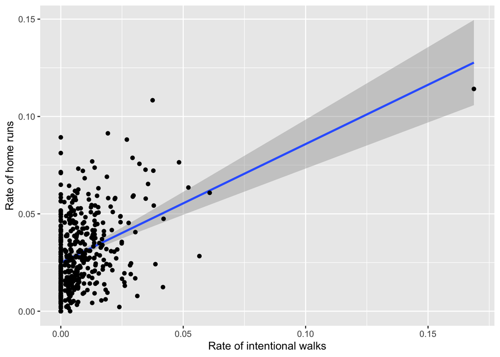

```r
q <- ggplot(batting, aes(x = (batting$IBB/batting$AB), y = (batting$HR/batting$AB))) +
     xlab("Rate of intentional walks") +
     ylab("Rate of home runs") +
     stat_smooth(method = "lm") #Creates line of best fit
q + geom_point() #Creates scatterplot of the two rates
```

```r
#Outliers are identified by looking at the scatterplot (one around .17 and .12)
```

## BONUS Problem

*Reconsider the data set from a previous project containing data about the results of 2012 Olympics. I load the data in for you below:*

```r
# setwd("C:/Users/Deicy/Dropbox/Utah/MATH 3070 Fall 2018 - DJ/Lecture_7") #you will need to change to working directory to your own computer.
# olympic2012 <- read.csv("olympic-medals2012.csv")
# Some variables are read in as strings when, in truth, they are numeric (they separate thousands with commas, leading to them being read as strings). I fix this below using the transform function, which allows for modifying columns in a data frame using methods similar to with.
# olympic2012 <- transform(olympic2012, GDP.2011 = as.numeric(gsub(",", "", GDP.2011)), pop.2010 = as.numeric(gsub(",", "", pop.2010)))
```

*Use any plotting system (base R, **lattice**, **ggplot2**) to create plot involving at least three variables in the `olympic2012` data set. Explain the relationship you explored and any interesting findings. **Bonus points will be given for plots that I consider clean, clear, and insightful, accompanied with good analyses of what you found.***

```r
# Your code here
```